# Twitter LDA Topic Modeling

## 🧭 Overview & Setup

This tutorial walks you through on:

1. How to preprocess text for text analysis
2. How to perform a LDA topic modeling analysis
3. How to plot the top terms for each topic

### 📦 Install and load packages

Install the following packages if you do not have them in your R environment.

- `tidyverse` is a collection of R packages for data science
- `tidytext` is used to preprocess data for text mining
- `topicmodels` is used to perform Latent Dirichlet Allocation (LDA) topic modeling analysis
- `reshape2` is a dependency that may need to be installed manually
- `LDAvis` is used to interactively visualize topic modeling results using a web-based viewer

Note that the result of your analysis may differ based on the `tidytext` version. Specifically, the tokenizing logic from version `0.4.0` (released on December 20th, 2022) and above has been updated. `token = "tweets"` option has been deprecated and will throw an error. This notebook assumes that you’re using `tidytext` version `>=0.4.0`.

```r
# uncomment and run the lines below if you need to install these packages

# install.packages("tidyverse")
# install.packages("tidytext")
# install.packages("topicmodels")
# install.packages("reshape2")
# install.packages("LDAvis")
# install.packages("servr")
```

Load packages.

```r
library(tidyverse)
library(tidytext)
library(topicmodels)
library(reshape2)
library(LDAvis)
library(servr)
```

### 📃 Read CSV file

```r
df_tweets = read_csv('Lululemon-tweets.csv')
df_tweets %>% head()
```

| id | username | text |
| --- | --- | --- |
| 1.603435e+18 | demsRinsane | @GOPChairwoman YOU NEED TO RESIGN. Lululemon you smug bitch 🖕🏻🖕🏻🖕🏻🖕🏻🖕🏻🖕🏻🖕🏻🖕🏻🖕🏻🖕🏻🖕🏻 https://t.co/AIY8Pmywxe |
| 1.603434e+18 | sherbertkuma | i want the lululemon pink water bottle so bad LOL i've been eyeing it for a couple months now but also i have so many water bottles already hahha |
| 1.603433e+18 | aidaampie | Only thing I want for Christmas is lululemon 🤭 life without my employee discount is not it |
| 1.603433e+18 | marinarodich | Check out this listing I just added to my #Poshmark closet: Lululemon Groove Pant SHR Flare *Nulu Color-Red Merlot Size-12 NWT. https://t.co/HQuLFfJbQj #shopmycloset @poshmarkapp |
| 1.603433e+18 | poshcitystore | Check out this listing I just found on #Poshmark: Lululemon Base Pace High-Rise Running Tight 25" in Floral Electric. https://t.co/7DCkj9q7o9 #shopmycloset @poshmarkapp |
| 1.603432e+18 | marinarodich | Check out this listing I just added to my #Poshmark closet: Lululemon Groove Pant SHR Flare *Nulu Color-Red Merlot Size-12 NWT. https://t.co/7QjMkOyDeQ #shopmycloset @poshmarkapp |

Print out the number of rows.

```r
nrow(df_tweets)
```

```
## [1] 4516
```

## 🔨 Text Pre-processing

### 📌 Add row number to df_tweets

Create a new column named `row_num` with unique values in each row. This allows us to group by each tweet after we tokenize the tweet text.

```r
df_tweets$row_num <- seq_len(nrow(df_tweets))
df_tweets %>% head() %>% select(-text)
```

| id | username | row_num |
| --- | --- | --- |
| 1.603435e+18 | demsRinsane | 1 |
| 1.603434e+18 | sherbertkuma | 2 |
| 1.603433e+18 | aidaampie | 3 |
| 1.603433e+18 | marinarodich | 4 |
| 1.603433e+18 | poshcitystore | 5 |
| 1.603432e+18 | marinarodich | 6 |

### 🔗 Remove URLs

Many tweets contain URL strings in the form of “https://t.co/somestring”. Remove these URL strings using a regular expression

```r
df_tweets$text <- df_tweets$text %>%
  str_remove_all("https://t.co/\\w+")

df_tweets %>%
  select(text) %>%
  head()
```

| text |
| --- |
| @GOPChairwoman YOU NEED TO RESIGN. Lululemon you smug bitch 🖕🏻🖕🏻🖕🏻🖕🏻🖕🏻🖕🏻🖕🏻🖕🏻🖕🏻🖕🏻🖕🏻 |
| i want the lululemon pink water bottle so bad LOL i've been eyeing it for a couple months now but also i have so many water bottles already hahha |
| Only thing I want for Christmas is lululemon 🤭 life without my employee discount is not it |
| Check out this listing I just added to my #Poshmark closet: Lululemon Groove Pant SHR Flare *Nulu Color-Red Merlot Size-12 NWT. #shopmycloset @poshmarkapp |
| Check out this listing I just found on #Poshmark: Lululemon Base Pace High-Rise Running Tight 25" in Floral Electric. #shopmycloset @poshmarkapp |
| Check out this listing I just added to my #Poshmark closet: Lululemon Groove Pant SHR Flare *Nulu Color-Red Merlot Size-12 NWT. #shopmycloset @poshmarkapp |

### ⚔️ Tokenize and normalize

Tokenize tweet texts and normalize the tokens.

```r
# tokenize using unnest_tokens()
# this also normalizes the tokens (lowercase, remove punctuations except Twitter-specific characters for mentions, tickers, and URLs)
# token = "tweets" preserves usernames and hashtags
df_tokens <- df_tweets %>%
  tidytext::unnest_tokens(input = text, output = word)

df_tokens %>% head(n = 10)
```

| id | username | row_num | word |
| --- | --- | --- | --- |
| 1.603435e+18 | demsRinsane | 1 | gopchairwoman |
| 1.603435e+18 | demsRinsane | 1 | you |
| 1.603435e+18 | demsRinsane | 1 | need |
| 1.603435e+18 | demsRinsane | 1 | to |
| 1.603435e+18 | demsRinsane | 1 | resign |
| 1.603435e+18 | demsRinsane | 1 | lululemon |
| 1.603435e+18 | demsRinsane | 1 | you |
| 1.603435e+18 | demsRinsane | 1 | smug |
| 1.603435e+18 | demsRinsane | 1 | bitch |
| 1.603434e+18 | sherbertkuma | 2 | i |

### 🪓 Remove stop words

Stop words are words that are commonly used and likely unimportant. Examples include “is”, “by”, “the”, “a”, etc.

```r
# remove stop words using anti_join
# and remove tokens with only 1 or 2 characters
df_tokens <- df_tokens %>%
  anti_join(tidytext::stop_words, by = "word") %>%
  filter(nchar(word) >= 3)

df_tokens %>% head(n = 10)
```

| id | username | row_num | word |
| --- | --- | --- | --- |
| 1.603435e+18 | demsRinsane | 1 | gopchairwoman |
| 1.603435e+18 | demsRinsane | 1 | resign |
| 1.603435e+18 | demsRinsane | 1 | lululemon |
| 1.603435e+18 | demsRinsane | 1 | smug |
| 1.603435e+18 | demsRinsane | 1 | bitch |
| 1.603434e+18 | sherbertkuma | 2 | lululemon |
| 1.603434e+18 | sherbertkuma | 2 | pink |
| 1.603434e+18 | sherbertkuma | 2 | water |
| 1.603434e+18 | sherbertkuma | 2 | bottle |
| 1.603434e+18 | sherbertkuma | 2 | bad |

### 🔮 Most frequent tokens

```r
df_tokens %>% count(word) %>% arrange(desc(n))
```

| word | n |
| --- | --- |
| lululemon | 4491 |
| check | 1361 |
| poshmark | 1311 |
| poshmarkapp | 1311 |
| shopmycloset | 1310 |
| listing | 1276 |
| closet | 1222 |
| added | 1221 |
| lulu | 468 |
| size | 426 |

[output cut: 7784 more lines]

## 🔨 LDA Analysis

### 📐 Create a Document-term Matrix

- Each row in our Document-term Matrix represents a tweet.
- Each column represents a word (e.g., “bankruptcy”).
- Each cell contains the frequency of the word.

```r
dtm <- df_tokens %>%
  count(row_num, word) %>%
  cast_dtm(document = row_num, term = word, value = n)

dtm
```

```
## <<DocumentTermMatrix (documents: 4515, terms: 7794)>>
## Non-/sparse entries: 47787/35142123
## Sparsity           : 100%
## Maximal term length: 48
## Weighting          : term frequency (tf)
```

### 🧪 Run LDA with 3 topics (`k = 3`)

```r
tweets_lda <- topicmodels::LDA(dtm, k = 3, control = list(seed = 12))
tweets_lda
```

```
## A LDA_VEM topic model with 3 topics.
```

Print out per-topic-per-word probabilities.

**beta** values are the probabilities of words in each topic.

```r
tweet_topics <- tidytext::tidy(tweets_lda, matrix = "beta")

top_terms <- tweet_topics %>%
  group_by(topic) %>%
  slice_max(beta, n = 20) %>%
  ungroup() %>%
  arrange(topic, -beta)

top_terms
```

| topic | term | beta |
| --- | --- | --- |
| 1 | lululemon | 0.091726068 |
| 1 | poshmark | 0.064125891 |
| 1 | listing | 0.037191175 |
| 1 | closet | 0.032374210 |
| 1 | added | 0.030900278 |
| 1 | poshmarkapp | 0.027761416 |
| 1 | check | 0.013568390 |
| 1 | tank | 0.010188724 |
| 1 | stocks | 0.009777794 |
| 1 | lulu | 0.009256346 |

[output cut: 50 more lines]

### 📊 Plot the top 20 terms

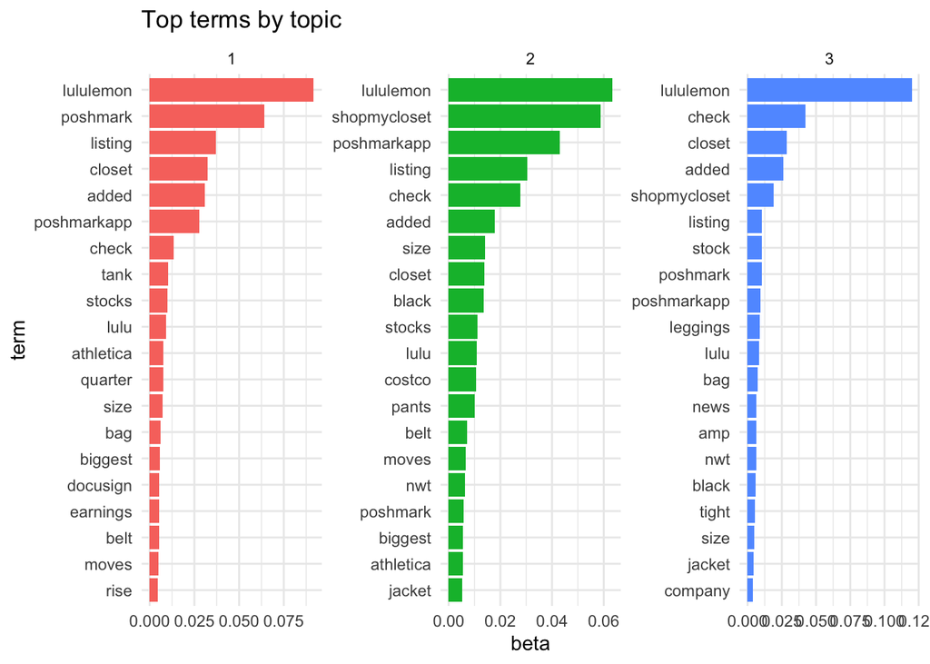

```r
top_terms %>%
  mutate(term = reorder_within(term, beta, topic)) %>%
  ggplot(aes(beta, term, fill = factor(topic)))+
  geom_col(show.legend = FALSE) +
  theme_minimal() +
  ggtitle("Top terms by topic") +
  facet_wrap(~topic, scales = "free") +
  scale_y_reordered()
```

### 🌌 (Optional) Intertopic Distance Map

The intertopic distance map will not be shown in the knitted HTML file. Run the R notebook to see the intertopic distance map.

```r
post <- topicmodels::posterior(tweets_lda)
mat <- tweets_lda@wordassignments
json <- LDAvis::createJSON(
    phi = post$terms,
    theta = post$topics,
    vocab = colnames(post$terms),
    doc.length = slam::row_sums(mat, na.rm = TRUE),
    term.frequency = slam::col_sums(mat, na.rm = TRUE)
)
serVis(json)
```